# Lab 7 Introduction to Computational Finance

# task 1 Loading in your data set

- Load the data with the help of the load function.
- Use head and tail to explore the returns_df data set.

```r
# Load relevant packages
library("PerformanceAnalytics")
library("zoo")

# Load the data
load(url("http://s3.amazonaws.com/assets.datacamp.com/course/compfin/lab8.RData"))
# Explore the data set
head(returns_df)
```

```
##                 rboeing       rmsft
## 1992-07-01  0.003133855  0.03853916
## 1992-08-01 -0.071232544  0.02375398
## 1992-09-01 -0.013508615  0.07745886
## 1992-10-01 -0.020622782  0.09758069
## 1992-11-01 -0.024602276  0.04811259
## 1992-12-01  0.133085160 -0.08689424
```

```r
tail(returns_df)
```

```
##                rboeing      rmsft
## 2000-05-01 -0.01221301 -0.1087514
## 2000-06-01  0.06803470  0.2458606
## 2000-07-01  0.15478898 -0.1362136
## 2000-08-01  0.09720903  0.0000000
## 2000-09-01  0.18435738 -0.1462737
## 2000-10-01  0.05008115  0.1327539
```

# task 2 The CER model

- Assign to sigma2_annual the estimates of $s^2_i$ for both assets (i.e. i= Boeing and Microsoft respectively). Calculate the corresponding $\hat{s}i$ as well and assign it to sigma_annual.
- The annual CER model parameters for Boeing are provided. Calculate those for Microsoft as well.
- Estimate the correlations $\rho ij$ between both stocks and assign the result to rho_boeing_msft.

```r
# The returns_df data is preloaded in your workspace

# Estimate the parameters: multivariate
mu_hat_annual <- apply(returns_df,2,mean)*12
sigma2_annual <- apply(returns_df,2,var)*12
sigma_annual <- sqrt(sigma2_annual)
cov_mat_annual <- cov(returns_df)*12
cov_hat_annual <- cov(returns_df)[1,2]*12
rho_hat_annual <- cor(returns_df)[1,2]

# The annual estimates of the CER model parameters for Boeing and Microsoft
mu_boeing <- mu_hat_annual["rboeing"]
mu_msft <- mu_hat_annual["rmsft"]
sigma2_boeing <-  sigma2_annual["rboeing"]
sigma2_msft <- sigma2_annual["rmsft"]
sigma_boeing <- sigma_annual["rboeing"]
sigma_msft <- sigma_annual['rmsft']
sigma_boeing_msft <- cov_hat_annual
rho_boeing_msft <- rho_hat_annual
```

# task 3 A portfolio of Boeing and Microsoft stock

- The boeing_weights variable is given. Calculate the corresponding value of msft_weights and take into account that the sum of the portfolio weights should be one.
- Assign to mu_portfolio the expected portfolio returns $\mu p$ for each set of portfolio weights.
- Assign to sigma2_portfolio the portfolio variances $\sigma^2_p$ for each set of portfolio weights.
- Have a look at the code to generate the plot on the right. Add the label “Boeing” and “Microsoft” on the right place in the risk-return plot. Are you not sure what is happening there? Have a look at the documentation of the text() function.

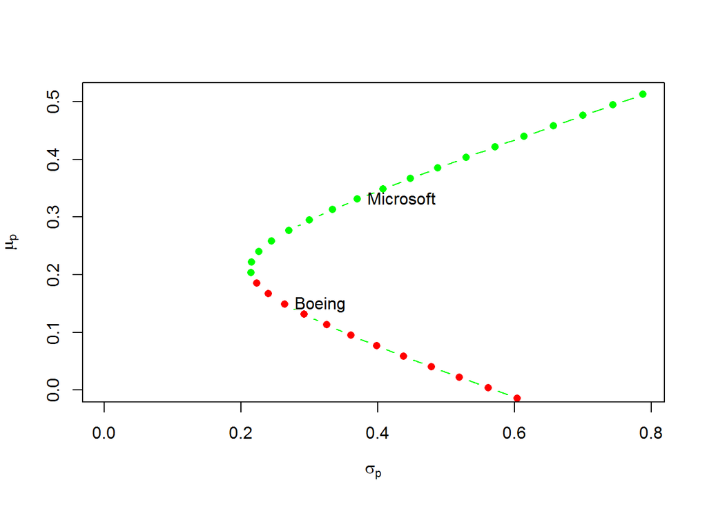

```r
# All data and CER parameters are preloaded in your workspace.
# Type "ls()" in the console to see them.

# The ratio Boeing stock vs Microsoft stock (adds up to 1)
boeing_weights <- seq(from=-1, to=2, by=0.1)
msft_weights <- 1 - boeing_weights

# Portfolio parameters
mu_portfolio <-  boeing_weights*mu_boeing + msft_weights*mu_msft
sigma2_portfolio <-  boeing_weights^2 * sigma2_boeing + msft_weights^2 * sigma2_msft + 2*boeing_weights*msft_weights*sigma_boeing_msft
sigma_portfolio <- sqrt(sigma2_portfolio)

# Plotting the different portfolios
plot(sigma_portfolio, mu_portfolio, type="b", pch=16, ylim=c(0, max(mu_portfolio)), xlim=c(0, max(sigma_portfolio)), xlab=expression(sigma[p]), ylab=expression(mu[p]),col=c(rep("green", 18), rep("red", 13)))
text(x=sigma_boeing, y=mu_boeing, labels="Boeing", pos=4)
text(x=sigma_msft, y=mu_msft, labels="Microsoft", pos=4)
```

# task 4 Adding T-bills to your portfolios

- Assign to t_bill_rate the annual risk-free rate of 3%.
- Calculate the expected portfolio return and portfolio variance for this set of portfolios.
- Add these new portfolio combinations to the plot that you constructed in the previous exercise with the help of points. For the color code argument use col=“blue”, for the type use type=“b”.

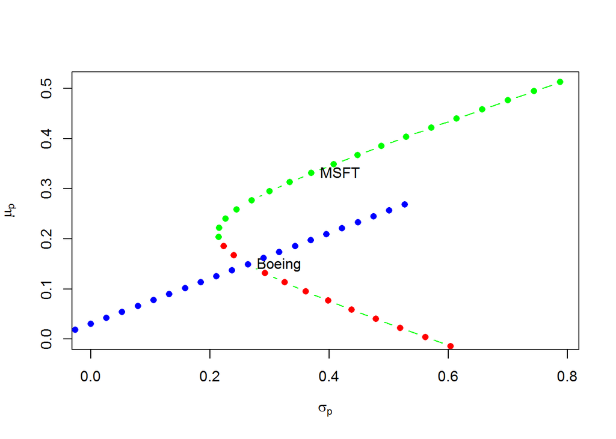

```r
# All data and CER parameters are preloaded in your workspace.
# Type "ls()" in the console to see them.

# Annual risk-free rate of 3% per year for the T-bill
t_bill_rate <- 0.03

# Ratio Boeing stocks
boeing_weights <- seq(from=-1, to=2, by=0.1)
t_bill_weights <- 1 - boeing_weights

# Portfolio parameters
mu_portfolio_boeing_bill <- boeing_weights*mu_boeing + t_bill_weights *t_bill_rate

sigma_portfolio_boeing_bill <- boeing_weights*sigma_boeing

# Plot previous exercise
plot(sigma_portfolio, mu_portfolio, type="b", pch=16, ylim=c(0, max(mu_portfolio)), xlim=c(0, max(sigma_portfolio)), xlab=expression(sigma[p]), ylab=expression(mu[p]),col=c(rep("green", 18), rep("red", 13)))
text(x=sigma_boeing, y=mu_boeing, labels="Boeing", pos=4)
text(x=sigma_msft, y=mu_msft, labels="MSFT", pos=4)

# Portfolio Combination Boeing and T-bills
points(sigma_portfolio_boeing_bill,mu_portfolio_boeing_bill,type = "b",pch = 16, col="blue" )
```

# task 5 The Sharpe Slope

- Calculate the Sharpe slope for Boeing and assign your result to sharp_ratio_boeing.

```r
sharp_ratio_boeing <- (mu_boeing-t_bill_rate)/sigma_boeing
sharp_ratio_msft <- (mu_msft-t_bill_rate)/sigma_msft
```

# task 6 Global Minimum Variance Portfolio

- Assign the global minimum variance portfolio to global_min_var_portfolio and print the result to the console.
- Apply the summary() function to global_min_var_portfolio. Set the risk.free argument to 3% to get the portfolio Sharpe ratio.
- Make a plot with the plot() function that shows the weight of Boeing and Microsoft in global minimum variance portfolio.

```r
# All data and CER parameters are preloaded in your workspace.
# Type "ls()" in the console to see them.
source("portfolio.r")
# The global minimum variance portfolio
global_min_var_portfolio <- globalMin.portfolio(mu_hat_annual, cov_mat_annual)

global_min_var_portfolio
```

```
## Call:
## globalMin.portfolio(er = mu_hat_annual, cov.mat = cov_mat_annual)
##
## Portfolio expected return:     0.2105954
## Portfolio standard deviation:  0.2139033
## Portfolio weights:
## rboeing   rmsft
##   0.662   0.338
```

```r
# Summary of global_min_var_portfolio that takes into account the annual risk-free rate of 3% per year
summary(global_min_var_portfolio, risk.free = 0.03)
```

```
## Call:
## globalMin.portfolio(er = mu_hat_annual, cov.mat = cov_mat_annual)
##
## Portfolio expected return:     0.2105954
## Portfolio standard deviation:  0.2139033
## Portfolio Sharpe Ratio:        0.8442854
## Portfolio weights:
## rboeing   rmsft
##   0.662   0.338
```

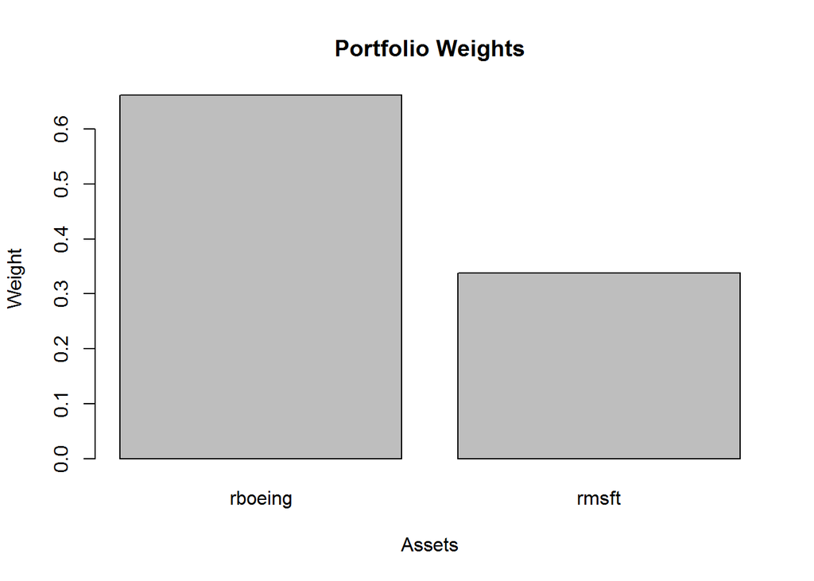

```r
# Portfolio weights Boeing and Microsoft
plot(global_min_var_portfolio)
```

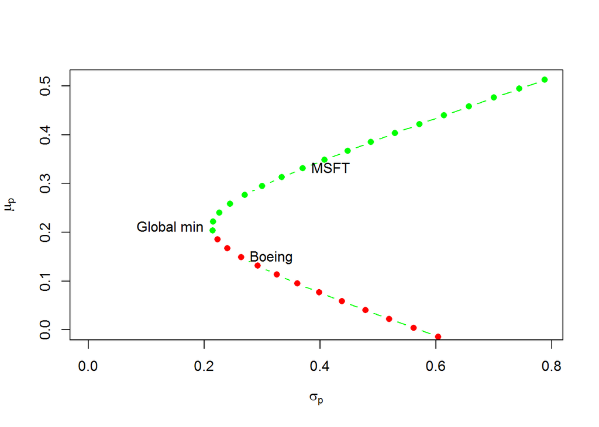

```r
# Plot previous exercises
plot(sigma_portfolio, mu_portfolio, type="b", pch=16, ylim=c(0, max(mu_portfolio)), xlim=c(0, max(sigma_portfolio)), xlab=expression(sigma[p]), ylab=expression(mu[p]),col=c(rep("green", 18), rep("red", 13)))
text(x=sigma_boeing, y=mu_boeing, labels="Boeing", pos=4)
text(x=sigma_msft, y=mu_msft, labels="MSFT", pos=4)

# Plot the position of the global minimum variance portfolio
text(x=global_min_var_portfolio$sd, y=global_min_var_portfolio$er, labels="Global min", pos=2)
```

# task 7 Tangency Portfolio

- Assign the tangency portfolio to tangency_portfolio and print the result.
- Study the summary of tangency_portfolio. Take into account a risk-free rate of 3%.
- Make a plot with the plot() function that shows the weight of Boeing and Microsoft in the tangency portfolio.

```r
# All data and CER parameters are preloaded in your workspace.
# Type "ls()" in the console to see them.

# The tangency portfolio
tangency_portfolio <-  tangency.portfolio(er = mu_hat_annual, cov.mat = cov_mat_annual, risk.free = 0.03)

tangency_portfolio
```

```
## Call:
## tangency.portfolio(er = mu_hat_annual, cov.mat = cov_mat_annual,
##     risk.free = 0.03)
##
## Portfolio expected return:     0.2507215
## Portfolio standard deviation:  0.2364756
## Portfolio weights:
## rboeing   rmsft
##  0.4409  0.5591
```

```r
# Summary of tangency_portfolio with annual risk free rate of 3%
summary(tangency_portfolio, risk.free = 0.03)
```

```
## Call:
## tangency.portfolio(er = mu_hat_annual, cov.mat = cov_mat_annual,
##     risk.free = 0.03)
##
## Portfolio expected return:     0.2507215
## Portfolio standard deviation:  0.2364756
## Portfolio Sharpe Ratio:        0.9333793
## Portfolio weights:
## rboeing   rmsft
##  0.4409  0.5591
```

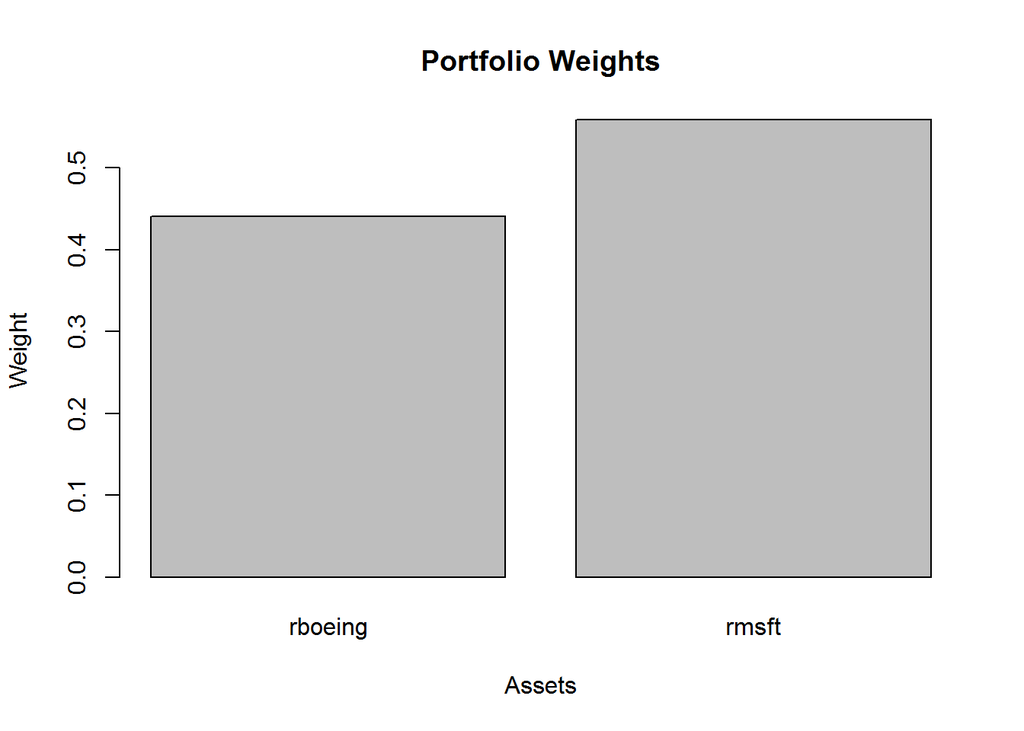

```r
# Portfolio weights Boeing and Microsoft
plot(tangency_portfolio)
```

# Task 8 Tangency portfolio and T-bills

- Calculate the expected portfolio returns mu_portfolio_tangency_bill and portfolio volatilities sigma_portfolio_tangency_bill for the set of weights and indicate the proportion that was invested in the tangency portfolio (tangency_weights).
- Add these new portfolios to the plot that you constructed in the previous exercise with the help of the points() function. For the color code argument use col=“blue”, for the type use type=“b”, and as a plotting character use pch=16.

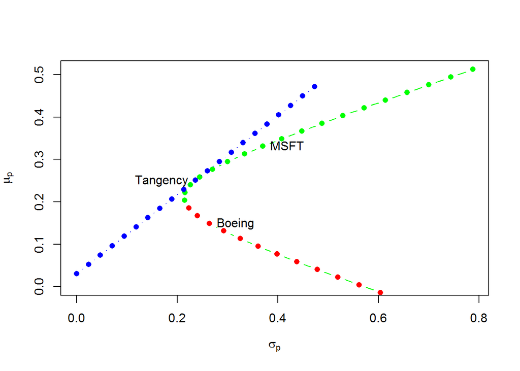

```r
# All data and CER parameters are preloaded in your workspace.
# Type "ls()" in the console to see them.

# Annual risk-free rate of 3% per year for the T-bill
t_bill_rate <- 0.03

# Set of tangency portfolio weights
tangency_weights <- seq(from=0, to=2, by=0.1)

# Portfolio parameters
mu_portfolio_tangency_bill <- tangency_portfolio$er*tangency_weights + (1-tangency_weights)*t_bill_rate

sigma_portfolio_tangency_bill <- tangency_weights*tangency_portfolio$sd

# Plot previous exercises
plot(sigma_portfolio, mu_portfolio, type="b", pch=16, ylim=c(0, max(mu_portfolio)), xlim=c(0, max(sigma_portfolio)), xlab=expression(sigma[p]), ylab=expression(mu[p]),col=c(rep("green", 18), rep("red", 13)))
text(x=sigma_boeing, y=mu_boeing, labels="Boeing", pos=4)
text(x=sigma_msft, y=mu_msft, labels="MSFT", pos=4)

# Plot portfolio combinations of tangency portfolio and T-bills
text(x=tangency_portfolio$sd, y=tangency_portfolio$er, labels="Tangency", pos=2)
points(sigma_portfolio_tangency_bill,mu_portfolio_tangency_bill,type="b",pch = 16, col = "blue")
```

# Task 9 An Efficient Portfolio with 30% Tangency

- Set the tangency_weight to 0.3 and then determine the t_bill_weight.
- Assign to mu_portfolio_efficient the expected portfolio return and to sd_portfolio_efficient the portfolio standard deviation.
- Plot this portfolio using points. Use “orange”" as the color for the line, the type is “b”, the plotting character is 16, and apply a character expansion cex of 2. The corresponding text() function is already provided.

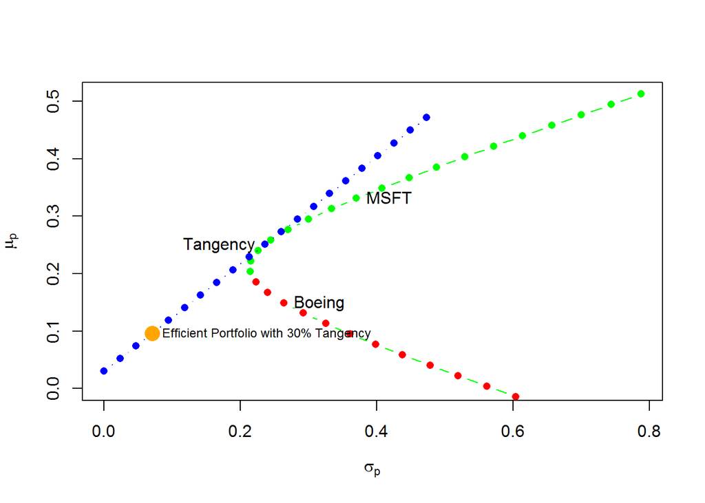

```r
# All data and CER parameters are preloaded in your workspace.
# Type "ls()" in the console to see them.

# Define the portfolio ratio's
tangency_weight <- 0.3
t_bill_weight <- 1 - tangency_weight

# Define the portfolio parameters
mu_portfolio_efficient <- tangency_weight*tangency_portfolio$er + t_bill_weight*t_bill_rate

sd_portfolio_efficient <- tangency_weight*tangency_portfolio$sd

# Plot previous exercises
plot(sigma_portfolio, mu_portfolio, type="b", pch=16, ylim=c(0, max(mu_portfolio)), xlim=c(0, max(sigma_portfolio)), xlab=expression(sigma[p]), ylab=expression(mu[p]),col=c(rep("green", 18), rep("red", 13)))
text(x=sigma_boeing, y=mu_boeing, labels="Boeing", pos=4)
text(x=sigma_msft, y=mu_msft, labels="MSFT", pos=4)
text(x=tangency_portfolio$sd, y=tangency_portfolio$er, labels="Tangency", pos=2)
points(sigma_portfolio_tangency_bill, mu_portfolio_tangency_bill, type="b", col="blue", pch=16)

# Plot Efficient Portfolio with 30% Tangency

text(x=sd_portfolio_efficient, y=mu_portfolio_efficient, labels="Efficient Portfolio with 30% Tangency", pos=4, cex=0.75)

points(sd_portfolio_efficient,mu_portfolio_efficient, type="b",cex = 2, pch = 16, col = "orange")
```

# Task 10 An Efficient Portfolio with the SD of Boeing

- Assign the weight of the tangency portfolio to tangency_weight.
- Calculate the portfolio parameters for this portfolio and assign them to mu_portfolio_efficient and sd_portfolio_efficient.
- Have a look at the plot.

[figure not shown]

```r
# All data and CER parameters are preloaded in your workspace.
# Type "ls()" in the console to see them.

# Define the tangency portfolio ratio
tangency_weight  <- sigma_boeing/tangency_portfolio$sd

# Calculate the weight of the tangency portfolio in the portfolio
mu_portfolio_efficient <- t_bill_rate + tangency_weight*(tangency_portfolio$er - t_bill_rate)
sd_portfolio_efficient <- tangency_weight*tangency_portfolio$sd

# Plot previous exercises
plot(sigma_portfolio, mu_portfolio,bg="NA", type="b", pch=16, ylim=c(0, max(mu_portfolio)), xlim=c(0, max(sigma_portfolio)), xlab=expression(sigma[p]), ylab=expression(mu[p]),col=c(rep("green", 18), rep("red", 13)))
text(x=sigma_boeing, y=mu_boeing, labels="Boeing", pos=4)
text(x=sigma_msft, y=mu_msft, labels="MSFT", pos=4)
text(x=tangency_portfolio$sd, y=tangency_portfolio$er, labels="Tangency", pos=2)
points(sigma_portfolio_tangency_bill, mu_portfolio_tangency_bill, type="b", col="blue", pch=16)

# Plot Efficient Portfolio with the same risk as Boeing
points(sd_portfolio_efficient, mu_portfolio_efficient, type="p", col="orange", pch=16, cex=2)
text(x=sd_portfolio_efficient, y=mu_portfolio_efficient, labels="Efficient Portfolio with same risk as Boeing", pos=2, cex=0.75)
```

[figure not shown]

```r
tangency_weight  <- sigma_msft/tangency_portfolio$sd

# Calculate the weight of the tangency portfolio in the portfolio
mu_portfolio_efficient <- t_bill_rate + tangency_weight*(tangency_portfolio$er - t_bill_rate)
sd_portfolio_efficient <- tangency_weight*tangency_portfolio$sd

# Plot previous exercises
plot(sigma_portfolio, mu_portfolio,bg="NA", type="b", pch=16, ylim=c(0, max(mu_portfolio)), xlim=c(0, max(sigma_portfolio)), xlab=expression(sigma[p]), ylab=expression(mu[p]),col=c(rep("green", 18), rep("red", 13)))
text(x=sigma_boeing, y=mu_boeing, labels="Boeing", pos=4)
text(x=sigma_msft, y=mu_msft, labels="MSFT", pos=4)
text(x=tangency_portfolio$sd, y=tangency_portfolio$er, labels="Tangency", pos=2)
points(sigma_portfolio_tangency_bill, mu_portfolio_tangency_bill, type="b", col="blue", pch=16)

# Plot Efficient Portfolio with the same risk as Boeing
points(sd_portfolio_efficient, mu_portfolio_efficient, type="p", col="orange", pch=16, cex=2)
text(x=sd_portfolio_efficient, y=mu_portfolio_efficient, labels="Efficient Portfolio with same risk as Boeing", pos=2, cex=0.75)
```